# POLS 3604

Lecture 14 | Legislative Effectiveness

## Plan for Today

- Discuss institutional effectiveness

## Legislative Effectiveness

- We can think about legislative effectiveness in two ways:
  - Institutional Effectiveness
    - Congress’s governing responsibilities
  - Individual Effectiveness
    - Participating in the lawmaking process and representing their constituents

## Institutional Effectiveness

- We can think about this in terms of performance over time
  - Lawmaking, oversight, constituent service
- We shall focus on lawmaking
  - In order to keep the government operational Congress must perform the following tasks:
    - Authorizations
    - Annual budgets and appropriations
    - Federal debt
    - Major legislation
  - How well do we think Congress meets its responsibilities in these categories?

## Authorizations

- Authorizations
  - Establish or renew federal programs, agencies, and policies
- Authorizations can be either short term or long term
  - Short term: Few months or years
  - Long term: permanent or multiple years
- Short term authorizations go back to the Framers
  - Short term authorizations are more common
  - Works a safe guard
    - Groups can sound the alarm on bad policy
  - Provides committees with agenda control
  - Keeps interest groups engaged
    - Keeps donations flowing
- What happens when authorizations do not occur?
  - In many instances, agencies can continue on with day to day operations
  - Congress can issue the agency a waiver
    - Which provides the needed funds without reauthorization

## The Budget and Appropriations Process

- The budget process
  - Authorizing legislation
  - Budget resolution
  - appropriations legislation
- The president generally starts the budget process every February
  - Proposes a budget for the entire federal government
    - Includes estimates for revenues and expenditures, projections for future years, and budget requests for each agency
- Congress budget committees will hold hearings on the proposed budget
- By mid-April, the House and Senate are required to produce their concurrent budget resolution on the budget
  - Provide a target for spending, which guides congress when they are completing the appropriations bill
- This is conducted annually

## Appropriations

- Appropriations bills allow the Treasury to make payments for specific programs or agencies
- The Constitutions outlines the appropriations process
  - Article I, Section 9: No money shall be drawn from the Treasury, but in Consequence of Appropriations made by law
- Appropriations bills deal with **discretionary spending**
  - Money for things that the Executive and Legislative branches can change
- Appropriation bills do not change **mandatory spending**
  - Spending that happens automatically every year and does not need a appropriations bill
    - Interest on national debt, contractual obligations, entitlement spending
- Entitlement programs
  - Large government spending programs
    - Social Security, Medicare, Veterans’ Compensation

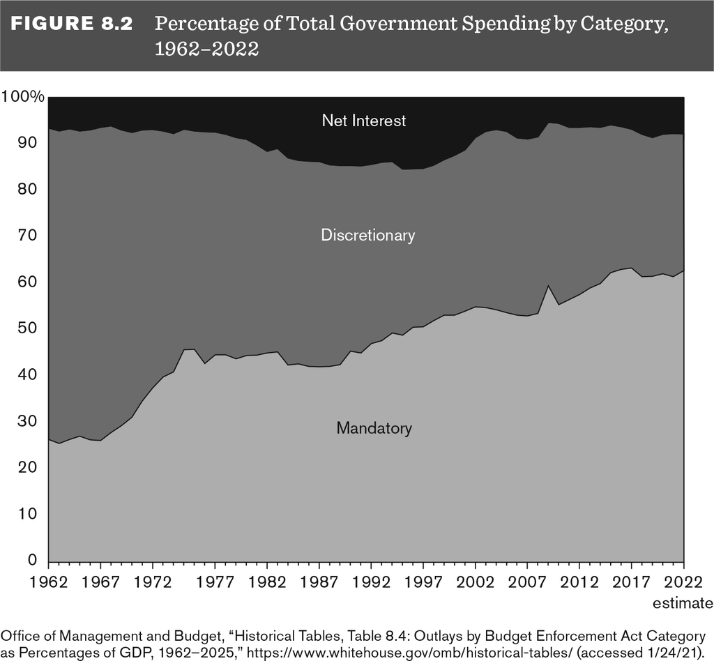

- Congress routinely fails to pass all appropriations measures separately
  - Lumps them together in omnibus bills
- Additionally, with increasing polarization, Congress rarely passes appropriations bills on time
  - Continuing Resolutions (CR)
    - Measure to fund programs and agencies until regular appropriations can be finalized
    - These are on the rise

## Funding Gaps and the Federal Debt Limit

- Government shutdowns occur when a continuing resolution cannot be passes (or better yet regular appropriations bills)
- Based on spending, we run at a deficit
  - We spend more money than we take in annually with tax revenue
- What happens if we default?

## Final Thoughts

- Congress rarely follows the textbook version of its duties as it pertains to appropriations
- Based on the metrics that we have discussed today, it would appear that Congress is having increased difficulty fulfilling its governing responsibilities